# 5301_project_2

HB

2024-03-03

## Introduction

This document reviews **COVID19 Data Report** based on a dataset retrieved from Johns Hopkins University data repository.The purpose of this document is to review the Covid19 data and produce educational visuals and models. The general trend of change in the number of cases and deaths are analysed throughout 2020-2023 followed by a deep dive into the states of Washington and California. Finally, the relationship between the population is analyzed to create a predictionb model.

## Requirements

The following libraries are used in this module: tidyverse, zoo, dplyr, ggplot2,

## Importing the Data

To keep this analysis reproducible, data is directly imported into the environment from the source repository. Since this dataset covers a lot of details. It needs to go through filtering and conditioning before analysis. In the next few steps the dataset is prepared in a more plot friendly format. Here is a sample of unfiltered data of US cases:

```r
url_in <- "https://raw.githubusercontent.com/CSSEGISandData/COVID-19/master/csse_covid_19_data/csse_covid_19_time_series/"

file_names <- c("time_series_covid19_confirmed_US.csv",
                "time_series_covid19_deaths_US.csv")
urls <- str_c(url_in, file_names)
US_cases <- read_csv(urls[1])
US_deaths <- read_csv(urls[2])
head(US_cases,5)
```

| UID | iso2 | iso3 | code3 | FIPS | Admin2 | Province_State | Country_Region | Lat | Long_ | Combined_Key | 1/22/20 | 1/23/20 | 1/24/20 | 1/25/20 | 1/26/20 | 1/27/20 | 1/28/20 | 1/29/20 | 1/30/20 | 1/31/20 | 2/1/20 | 2/2/20 | 2/3/20 | 2/4/20 | 2/5/20 | 2/6/20 | 2/7/20 | 2/8/20 | 2/9/20 | … |
| --- | --- | --- | --- | --- | --- | --- | --- | --- | --- | --- | --- | --- | --- | --- | --- | --- | --- | --- | --- | --- | --- | --- | --- | --- | --- | --- | --- | --- | --- | --- |
| 84001001 | US | USA | 840 | 1001 | Autauga | Alabama | US | 32.53953 | -86.64408 | Autauga, Alabama, US | 0 | 0 | 0 | 0 | 0 | 0 | 0 | 0 | 0 | 0 | 0 | 0 | 0 | 0 | 0 | 0 | 0 | 0 | 0 | … |
| 84001003 | US | USA | 840 | 1003 | Baldwin | Alabama | US | 30.72775 | -87.72207 | Baldwin, Alabama, US | 0 | 0 | 0 | 0 | 0 | 0 | 0 | 0 | 0 | 0 | 0 | 0 | 0 | 0 | 0 | 0 | 0 | 0 | 0 | … |
| 84001005 | US | USA | 840 | 1005 | Barbour | Alabama | US | 31.86826 | -85.38713 | Barbour, Alabama, US | 0 | 0 | 0 | 0 | 0 | 0 | 0 | 0 | 0 | 0 | 0 | 0 | 0 | 0 | 0 | 0 | 0 | 0 | 0 | … |
| 84001007 | US | USA | 840 | 1007 | Bibb | Alabama | US | 32.99642 | -87.12511 | Bibb, Alabama, US | 0 | 0 | 0 | 0 | 0 | 0 | 0 | 0 | 0 | 0 | 0 | 0 | 0 | 0 | 0 | 0 | 0 | 0 | 0 | … |
| 84001009 | US | USA | 840 | 1009 | Blount | Alabama | US | 33.98211 | -86.56791 | Blount, Alabama, US | 0 | 0 | 0 | 0 | 0 | 0 | 0 | 0 | 0 | 0 | 0 | 0 | 0 | 0 | 0 | 0 | 0 | 0 | 0 | … |

As shown above, the raw data is not much plot friendly, thus to get a cleaner data the following steps are done: - Removing unnecessary columns “Lat” and “Long” - Pivoting the date columns - Merging overall cases along with the number of deaths - Removing data for dates with zero cases to keep the focus on the more valuable data Here is a snapshot of the cleaned US cases and death data:

| Admin2 | Province_State | date | cases | Population | deaths |
| --- | --- | --- | --- | --- | --- |
| Autauga | Alabama | 2020-03-24 | 1 | 55869 | 0 |
| Autauga | Alabama | 2020-03-25 | 5 | 55869 | 0 |
| Autauga | Alabama | 2020-03-26 | 6 | 55869 | 0 |
| Autauga | Alabama | 2020-03-27 | 6 | 55869 | 0 |
| Autauga | Alabama | 2020-03-28 | 6 | 55869 | 0 |

```
##     Admin2          Province_State          date                cases
##  Length:3468325     Length:3468325     Min.   :2020-01-22   Min.   :      1
##  Class :character   Class :character   1st Qu.:2020-12-27   1st Qu.:    690
##  Mode  :character   Mode  :character   Median :2021-09-20   Median :   2852
##                                        Mean   :2021-09-19   Mean   :  15502
##                                        3rd Qu.:2022-06-15   3rd Qu.:   9347
##                                        Max.   :2023-03-09   Max.   :3710586
##    Population           deaths
##  Min.   :       0   Min.   :    0.0
##  1st Qu.:   10953   1st Qu.:   10.0
##  Median :   26234   Median :   47.0
##  Mean   :  104571   Mean   :  205.4
##  3rd Qu.:   67997   3rd Qu.:  137.0
##  Max.   :10039107   Max.   :35545.0
```

### Check Data Validity

```
##     Admin2          Province_State          date                cases
##  Length:3420617     Length:3420617     Min.   :2020-01-22   Min.   :      1
##  Class :character   Class :character   1st Qu.:2020-12-27   1st Qu.:    699
##  Mode  :character   Mode  :character   Median :2021-09-20   Median :   2863
##                                        Mean   :2021-09-19   Mean   :  15563
##                                        3rd Qu.:2022-06-15   3rd Qu.:   9347
##                                        Max.   :2023-03-09   Max.   :3710586
##    Population           deaths
##  Min.   :      86   Min.   :    0.0
##  1st Qu.:   11663   1st Qu.:   10.0
##  Median :   26794   Median :   47.0
##  Mean   :  106029   Mean   :  204.3
##  3rd Qu.:   69761   3rd Qu.:  138.0
##  Max.   :10039107   Max.   :35545.0
```

When looking at the number of cases and deaths an important reference is the population on which this data has been retrieved. Thus comparing data without knowing the population is not valid. Fortunately the population data was already included in US deaths.

At this point the data is imported, cleaned, and validated. Therefore it is ready for analysis and modeling.

### Analyzing the US cases and Death

As mentioned before, to have a valid comparison among the number of cases or number of death between different areas, those numbers need to be unified based on the population. This can be done by looking at cases per million population as shown below.

```r
US_by_state <- US_all_clean %>%
    group_by(Province_State, date) %>%
    summarize(cases= sum(cases), deaths= sum(deaths), Population= sum(Population)) %>%
    mutate(deaths_per_mill= deaths* 1000000 / Population) %>%
    mutate(cases_per_mill= cases* 1000000 / Population) %>%
    ungroup()
head(US_by_state,5)
```

| Province_State | date | cases | deaths | Population | deaths_per_mill | cases_per_mill |
| --- | --- | --- | --- | --- | --- | --- |
| Alabama | 2020-03-11 | 3 | 0 | 534756 | 0 | 5.610035 |
| Alabama | 2020-03-12 | 4 | 0 | 907665 | 0 | 4.406912 |
| Alabama | 2020-03-13 | 8 | 0 | 1647447 | 0 | 4.855998 |
| Alabama | 2020-03-14 | 15 | 0 | 1647447 | 0 | 9.104997 |
| Alabama | 2020-03-15 | 28 | 0 | 2252925 | 0 | 12.428288 |

```r
US_totals <- US_all_clean %>%
    group_by(date) %>%
    summarize(cases= sum(cases), deaths= sum(deaths), Population= sum(Population)) %>%
    mutate(deaths_per_mill= deaths * 1000000 / Population) %>%
    mutate(cases_per_mill= cases* 1000000 / Population) %>%
    select(date,cases,deaths, cases_per_mill, deaths_per_mill, Population) %>%
    ungroup()
head(US_totals,5)
```

| date | cases | deaths | cases_per_mill | deaths_per_mill | Population |
| --- | --- | --- | --- | --- | --- |
| 2020-01-22 | 1 | 0 | 0.4438956 | 0 | 2252782 |
| 2020-01-23 | 1 | 0 | 0.4438956 | 0 | 2252782 |
| 2020-01-24 | 2 | 0 | 0.2701602 | 0 | 7403015 |
| 2020-01-25 | 2 | 0 | 0.2701602 | 0 | 7403015 |
| 2020-01-26 | 5 | 0 | 0.1991776 | 0 | 25103228 |

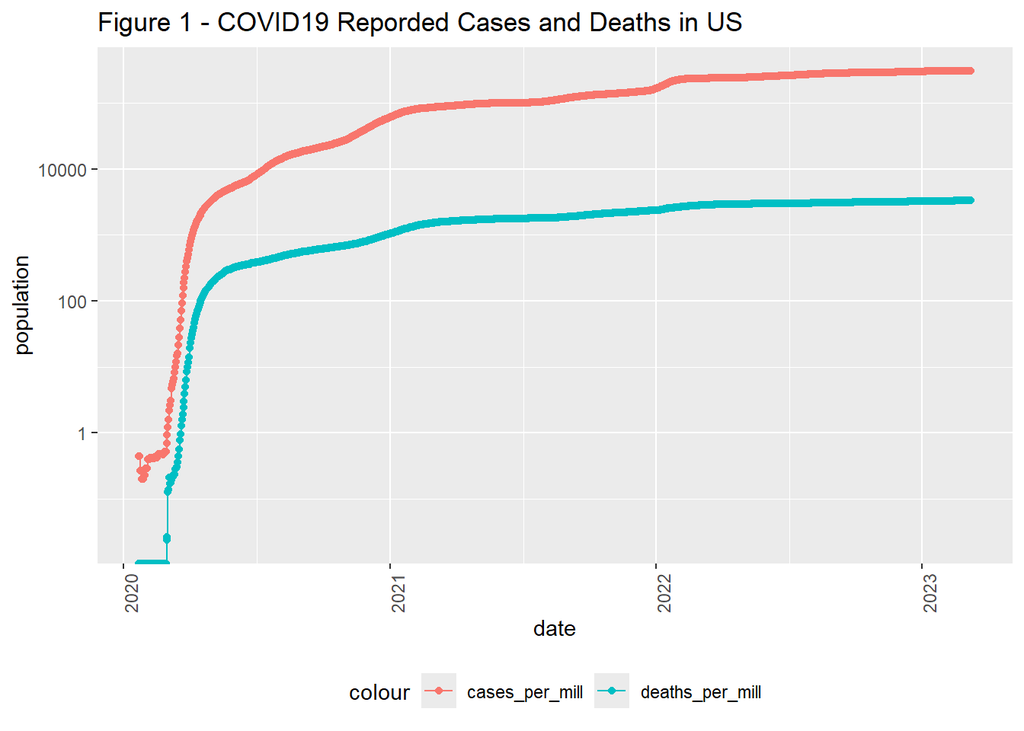

```r
US_totals %>%
    filter(cases_per_mill > 0) %>%
    ggplot(aes(x = date, y= cases_per_mill)) +
    geom_line(aes(color= "cases_per_mill")) +
    geom_point(aes(color= "cases_per_mill")) +
    geom_line(aes(y= deaths_per_mill, color= "deaths_per_mill")) +
    geom_point(aes(y= deaths_per_mill, color= "deaths_per_mill")) +
    scale_y_log10() +
    theme(legend.position = "bottom", axis.text.x = element_text(angle = 90)) +
    labs(title = "Figure 1 - COVID19 Reporded Cases and Deaths in US", y= "population")
```

As shown in figure 1, the total number of cases and deaths in US can simply be viewed over the tears. The main observation here is the big spike of the the growing number of cases during 2020 which plateaus by end of 2022. This could indicate the some measures that were implemented in US have been successful in controlling the increasing spread.

Looking more closely into the state of Washington and California:

```r
wa_cases <- US_by_state %>%
    filter(Province_State == "Washington")
ca_cases <- US_by_state %>%
    filter(Province_State == "California")
wa_ca <- wa_cases %>%
  left_join(ca_cases,by=c("date"))%>%
  rename(WA_deaths_per_mill = `deaths_per_mill.x`, WA_cases_per_mill = `cases_per_mill.x`)%>%
  rename(CA_deaths_per_mill = `deaths_per_mill.y`, CA_cases_per_mill = `cases_per_mill.y`)
wa_ca
```

| Province_State.x | date | cases.x | deaths.x | Population.x | WA_deaths_per_mill | WA_cases_per_mill | Province_State.y | cases.y | deaths.y | Population.y | CA_deaths_per_mill | CA_cases_per_mill |
| --- | --- | --- | --- | --- | --- | --- | --- | --- | --- | --- | --- | --- |
| Washington | 2020-01-22 | 1 | 0 | 2252782 | 0.0000000 | 4.438956e-01 | NA | NA | NA | NA | NA | NA |
| Washington | 2020-01-23 | 1 | 0 | 2252782 | 0.0000000 | 4.438956e-01 | NA | NA | NA | NA | NA | NA |
| Washington | 2020-01-24 | 1 | 0 | 2252782 | 0.0000000 | 4.438956e-01 | NA | NA | NA | NA | NA | NA |
| Washington | 2020-01-25 | 1 | 0 | 2252782 | 0.0000000 | 4.438956e-01 | NA | NA | NA | NA | NA | NA |
| Washington | 2020-01-26 | 1 | 0 | 2252782 | 0.0000000 | 4.438956e-01 | California | 2 | 0 | 13214799 | 0.000000e+00 | 1.513455e-01 |
| Washington | 2020-01-27 | 1 | 0 | 2252782 | 0.0000000 | 4.438956e-01 | California | 2 | 0 | 13214799 | 0.000000e+00 | 1.513455e-01 |
| Washington | 2020-01-28 | 1 | 0 | 2252782 | 0.0000000 | 4.438956e-01 | California | 2 | 0 | 13214799 | 0.000000e+00 | 1.513455e-01 |
| Washington | 2020-01-29 | 1 | 0 | 2252782 | 0.0000000 | 4.438956e-01 | California | 2 | 0 | 13214799 | 0.000000e+00 | 1.513455e-01 |
| Washington | 2020-01-30 | 1 | 0 | 2252782 | 0.0000000 | 4.438956e-01 | California | 2 | 0 | 13214799 | 0.000000e+00 | 1.513455e-01 |
| Washington | 2020-01-31 | 1 | 0 | 2252782 | 0.0000000 | 4.438956e-01 | California | 3 | 0 | 15142651 | 0.000000e+00 | 1.981159e-01 |

[output cut: 1133 more lines]

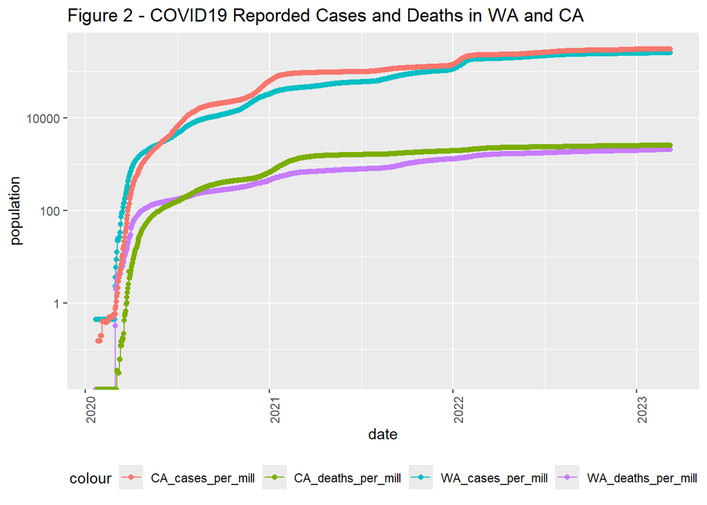

```r
wa_ca %>%
    ggplot(aes(x = date, y= WA_cases_per_mill)) +
    geom_line(aes(color= "WA_cases_per_mill")) +
    geom_point(aes(color= "WA_cases_per_mill")) +
    geom_line(aes(y= WA_deaths_per_mill, color= "WA_deaths_per_mill")) +
    geom_point(aes(y= WA_deaths_per_mill, color= "WA_deaths_per_mill")) +
    geom_line(aes(y= CA_cases_per_mill, color= "CA_cases_per_mill")) +
    geom_point(aes(y= CA_cases_per_mill, color= "CA_cases_per_mill")) +
    geom_line(aes(y= CA_deaths_per_mill, color= "CA_deaths_per_mill")) +
    geom_point(aes(y= CA_deaths_per_mill, color= "CA_deaths_per_mill")) +
    scale_y_log10() +
    theme(legend.position = "bottom", axis.text.x = element_text(angle = 90)) +
    labs(title = "Figure 2 - COVID19 Reporded Cases and Deaths in WA and CA", y= "population")
```

### Modeling the relationship between the total death and the population of states

First visualizing the existing data by summing all the death for each state

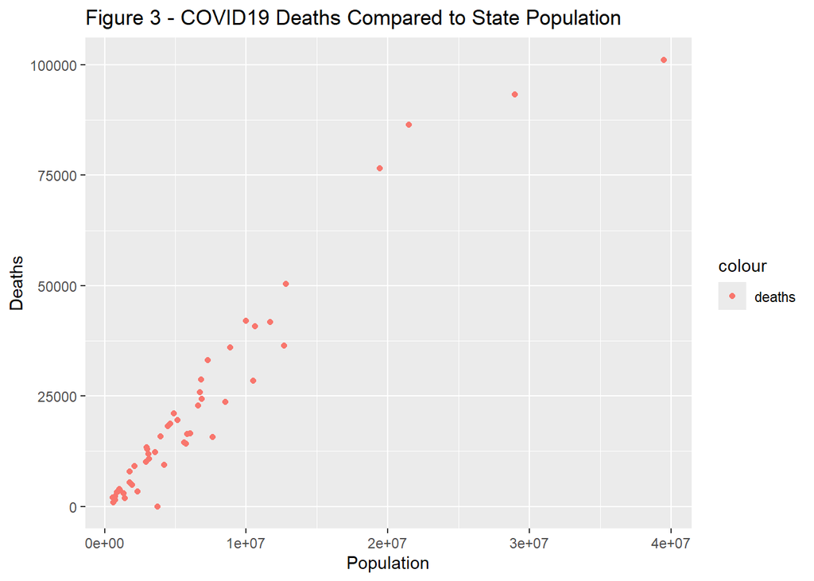

As shown in figure 3, there is a linear relation between the population of each state and the total number of deaths. Thus a linear model is created to predict the number of deaths based on any population.

```r
mod <- lm(deaths ~ Population, data = state_max)
summary(mod)
```

```
##
## Call:
## lm(formula = deaths ~ Population, data = state_max)
##
## Residuals:
##      Min       1Q   Median       3Q      Max
## -23227.3  -2754.7   -638.4   2759.5  18213.9
##
## Coefficients:
##              Estimate Std. Error t value Pr(>|t|)
## (Intercept) 1.374e+03  1.191e+03   1.153    0.254
## Population  3.113e-03  1.235e-04  25.203   <2e-16 ***
## ---
## Signif. codes:  0 '***' 0.001 '**' 0.01 '*' 0.05 '.' 0.1 ' ' 1
##
## Residual standard error: 6445 on 50 degrees of freedom
## Multiple R-squared:  0.927,  Adjusted R-squared:  0.9256
## F-statistic: 635.2 on 1 and 50 DF,  p-value: < 2.2e-16
```

```r
state_max <- state_max %>% mutate(death_pred = predict(mod))
head(state_max,5)
```

| Province_State | cases | deaths | Population | death_pred |
| --- | --- | --- | --- | --- |
| Alabama | 1644533 | 21032 | 4903185 | 16638.983 |
| Alaska | 307649 | 1486 | 728809 | 3643.016 |
| Arizona | 2443514 | 33102 | 7278717 | 24034.660 |
| Arkansas | 973278 | 13020 | 3017804 | 10769.279 |
| California | 12125315 | 101159 | 39512223 | 124386.325 |

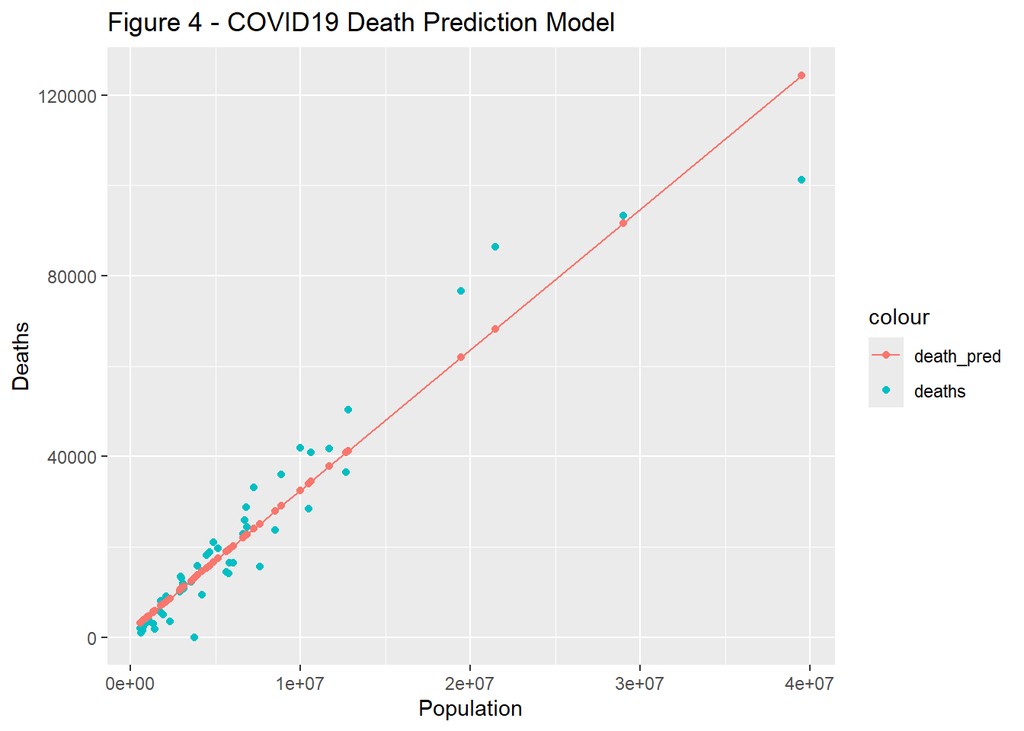

```r
state_max %>%
    ggplot(aes(x = Population, y= deaths)) +
    geom_point(aes(color= "deaths")) +
    geom_point(aes(y= death_pred, color= "death_pred")) +
    geom_line(aes(y= death_pred, color= "death_pred")) +
    labs(title = "Figure 4 - COVID19 Death Prediction Model", y= "Deaths")
```